# 30 | Coroutines：协作式的交叉调度执行

[figure not shown]

# 30 | Coroutines：协作式的交叉调度执行

2020-02-10 吴咏炜

现代C++实战30讲

[figure not shown]

### 讲述：吴咏炜

[interactive chart not shown]

你好，我是吴咏炜。

今天是我们未来篇的最后一讲，也是这个专栏正文内容的最后一篇了。我们讨论 C++20 里的又一个非常重要的新功能——协程 Coroutines。

## 什么是协程？

协程是一个很早就被提出的编程概念。根据高德纳的描述，协程的概念在 1958 年就被提出了。不过，它在主流编程语言中得到的支持不那么好，因而你很可能对它并不熟悉吧。

如果查阅维基百科，你可以看到下面这样的定义 [1]：

协程是计算机程序的⼀类组件，推⼴了协作式多任务的⼦程序，允许执⾏被挂起与被恢复。相对⼦例程⽽⾔，协程更为⼀般和灵活……

等学完了这一讲，也许你可以明白这段话的意思。但对不了解协程的人来说，估计只能吐槽一句了，这是什么鬼？

[figure not shown]

图片源自网络

很遗憾，在 C++ 里的标准协程有点小复杂。我们还是从……Python 开始。

def fibonacci():

a = 0

b = 1

while True:

yield b

a, b = b, a + b

即使你没学过 Python，上面这个生成斐波那契数列的代码应该也不难理解。唯一看起来让人会觉得有点奇怪的应该就是那个 yield 了。这种写法在 Python 里叫做“生成器”（generator），返回的是一个可迭代的对象，每次迭代就能得到一个 yield 出来的结果。这就是一种很常见的协程形式了。

如何使用这个生成器，请看下面的代码：

# 打印头 20 项

for i in islice(fibonacci(), 20):

print(i)

# 打印小于 10000 的数列项

for i in takewhile(

lambda x: x < 10000,

fibonacci()):

print(i)

这些代码很容易理解：islice 相当于 [第 29 讲] 中的 take，取一个范围的头若干项；takewhile 则在范围中逐项取出内容，直到第一个参数的条件不能被满足。两个函数的结果都可以被看作是 C++ 中的视图。

我们唯一需要提的是，在代码的执行过程中，fibonacci 和它的调用代码是交叉执行的。下面我们用代码行加注释的方式标一下：

a = 0 # fibonacci()

yield b # fibonacci()

print(i) # 调用者

a, b = 1, 0 + 1 # fibonacci()

yield b # fibonacci()

print(i) # 调用者

a, b = 1, 1 + 1 # fibonacci()

yield b # fibonacci()

print(i) # 调用者

a, b = 2, 1 + 2 # fibonacci()

yield b # fibonacci()

print(i) # 调用者

…

学到这儿的同学应该都知道我们在 C++ 里怎么完成类似的功能吧？我就不讲解了，直接给出可工作的代码。这是对应的 fibonacci 的定义：

#include <stddef.h>

#include <stdint.h>

class fibonacci {

public:

class sentinel;

class iterator;

iterator begin() noexcept;

sentinel end() noexcept;

};

class fibonacci::sentinel {};

class fibonacci::iterator {

public:

// Required to satisfy iterator

// concept

typedef ptrdiff_t difference_type;

typedef uint64_t value_type;

typedef const uint64_t* pointer;

typedef const uint64_t& reference;

typedef std::input_iterator_tag

iterator_category;

value_type operator*() const

{

return b_;

}

pointer operator->() const

{

return &b_;

}

iterator& operator++()

{

auto tmp = a_;

a_ = b_;

b_ += tmp;

return *this;

}

iterator operator++(int)

{

auto tmp = *this;

++*this;

return tmp;

}

bool

operator==(const sentinel&) const

{

return false;

}

bool

operator!=(const sentinel&) const

{

return true;

}

private:

uint64_t a_{0};

uint64_t b_{1};

};

// sentinel needs to be

// equality_comparable_with iterator

bool operator==(

const fibonacci::sentinel& lhs,

const fibonacci::iterator& rhs)

{

return rhs == lhs;

}

bool operator!=(

const fibonacci::sentinel& lhs,

const fibonacci::iterator& rhs)

{

return rhs != lhs;

}

inline fibonacci::iterator

fibonacci::begin() noexcept

{

return iterator();

}

inline fibonacci::sentinel

fibonacci::end() noexcept

{

return sentinel();

}

调用代码跟 Python 的相似：

// 打印头 20 项

for (auto i :

fibonacci() | take(20)) {

cout << i << endl;

}

// 打印小于 10000 的数列项

for (auto i :

fibonacci() |

take_while([](uint64_t x) {

return x < 10000;

})) {

cout << i << endl;

}

这似乎还行。但 fibonacci 的定义差异就大了：在 Python 里是 6 行有效代码，在 C++ 里是 53 行。C++ 的生产率似乎有点低啊……

## C++20 协程

C++20 协程的基础是微软提出的 Coroutines TS（可查看工作草案 [2]），它在 2019 年 7 月被批准加入到 C++20 草案中。目前，MSVC 和 Clang 已经支持协程。不过，需要提一下的是，目前被标准化的只是协程的底层语言支持，而不是上层的高级封装；稍后，我们会回到这个话题。

协程可以有很多不同的用途，下面列举了几种常见情况：

生成器

异步 I/O

惰性求值

事件驱动应用

这一讲中，我们主要还是沿用生成器的例子，向你展示协程的基本用法。异步 I/O 应当在协程得到广泛采用之后，成为最能有明显收益的使用场景；但目前，就我看到的，只有 Windows 平台上有较好的支持——微软目前还是做了很多努力的。

回到 Coroutines。我们今天采用 Coroutines TS 中的写法，包括 std::experimental 名空间，以确保你可以在 MSVC 和 Clang 下编译代码。首先，我们看一下协程相关的新关键字，有下面三个：

co_await

co_yield

co_return

这三个关键字最初是没有 co_ 前缀的，但考虑到 await、yield 已经在很多代码里出现，就改成了目前这个样子。同时，return 和 co_return 也作出了明确的区分：一个协程里只能使用 co_return，不能使用 return。这三个关键字只要有一个出现在函数中，这个函数就是一个协程了——从外部则看不出来，没有用其他语言常用的 async 关键字来标记（async 也已经有其他用途了，见 [第 19 讲]）。C++ 认为一个函数是否是一个协程是一个实现细节，不是对外接口的一部分。

我们看一下用协程实现的 fibonacci 长什么样子：

uint64_resumable fibonacci()

{

uint64_t a = 0;

uint64_t b = 1;

while (true) {

co_yield b;

auto tmp = a;

a = b;

b += tmp;

}

}

这个形式跟 Python 的非常相似了吧，也非常简洁。我们稍后再讨论 uint64_resumable 的定义，先看一下调用代码的样子：

auto res = fibonacci();

while (res.resume()) {

auto i = res.get();

if (i >= 10000) {

break;

}

cout << i << endl;

}

这个代码也非常简单，但我们需要留意 resume 和 get 两个函数调用——这就是我们的 uint64_resumable 类型需要提供的接口了。

### co_await、co_yield、co_return 和协程控制

在讨论该如何定义 uint64_resumable 之前，我们需要先讨论一下协程的这三个新关键字。

首先是 co_await。对于下面这样一个表达式：

auto result = co_await 表达式;

编译器会把它理解为：

auto&& __a = 表达式;

if (!__a.await_ready()) {

__a.await_suspend(协程句柄);

// 挂起/恢复点

}

auto result = __a.await_resume();

也就是说，“表达式”需要支持 await_ready、await_suspend 和 await_resume 三个接口。如果 await_ready() 返回真，就代表不需要真正挂起，直接返回后面的结果就可以；否则，执行 await_suspend 之后即挂起协程，等待协程被唤醒之后再返回 await_resume() 的结果。这样一个表达式被称作是个 awaitable。

标准里定义了两个 awaitable，如下所示：

struct suspend_always {

bool await_ready() const noexcept

{

return false;

}

void await_suspend(

coroutine_handle<>)

const noexcept {}

void await_resume()

const noexcept {}

};

struct suspend_never {

bool await_ready() const noexcept

{

return true;

}

void await_suspend(

coroutine_handle<>)

const noexcept {}

void await_resume()

const noexcept {}

};

也就是说，suspend_always 永远告诉调用者需要挂起，而 suspend_never 则永远告诉调用者不需要挂起。两者的 await_suspend 和 await_resume 都是平凡实现，不做任何实际的事情。一个 awaitable 可以自行实现这些接口，以定制挂起之前和恢复之后需要执行的操作。

上面的 coroutine_handle 是 C++ 标准库提供的类模板。这个类是用户代码跟系统协程调度真正交互的地方，有下面这些成员函数我们等会就会用到：

destroy：销毁协程

done：判断协程是否已经执行完成

resume：让协程恢复执行

promise：获得协程相关的 promise 对象（和 [第 19 讲] 中的“承诺量”有点相似，是协程和调用者的主要交互对象；一般类型名称为 promise_type）

from_promise（静态）：通过 promise 对象的引用来生成一个协程句柄

协程的执行过程大致是这个样子的：

为协程调用分配一个协程帧，含协程调用的参数、变量、状态、promise 对象等所需的空间。

调用 promise.get_return_object()，返回值会在协程第一次挂起时返回给协程的调用者。

执行 co_await promise.initial_suspsend()；根据上面对 co_await 语义的描述，协程可能在此第一次挂起（但也可能此时不挂起，在后面的协程体执行过程中挂起）。

执行协程体中的语句，中间可能有挂起和恢复；如果期间发生异常没有在协程体中处理，则调用 promise.unhandled_exception()。

当协程执行到底，或者执行到 co_return 语句时，会根据是否有非 void 的返回值，调用 promise.return_value(…) 或 promise.return_void()，然后执行 co_await promise.final_suspsend()。

用代码可以大致表示如下：

frame = operator new(…);

promise_type& promise =

frame->promise;

// 在初次挂起时返回给调用者

auto return_value =

promise.get_return_object();

co_await promise

.initial_suspsend();

try {

执行协程体;

可能被 co_wait、co_yield 挂起;

恢复后继续执行，直到 co_return;

}

catch (...) {

promise.unhandled_exception();

}

final_suspend:

co_await promise.final_suspsend();

上面描述了 co_await 和 co_return，那 co_yield 呢？也很简单，co_yield 表达式 等价于：

co_await promise.yield_value(表达式);

### 定义 uint64_resumable

了解了上述知识之后，我们就可以展示一下 uint64_resumable 的定义了：

class uint64_resumable {

public:

struct promise_type {…};

using coro_handle =

coroutine_handle<promise_type>;

explicit uint64_resumable(

coro_handle handle)

: handle_(handle)

{

}

~uint64_resumable()

{

handle_.destroy();

}

uint64_resumable(

const uint64_resumable&) =

delete;

uint64_resumable(

uint64_resumable&&) = default;

bool resume();

uint64_t get();

private:

coro_handle handle_;

};

这个代码相当简单，我们的结构内部有个 promise_type（下面会定义），而私有成员只有一个协程句柄。协程构造需要一个协程句柄，析构时将使用协程句柄来销毁协程；为简单起见，我们允许结构被移动，但不可复制（以免重复调用 handle_.destroy()）。除此之外，我们这个结构只提供了调用者需要的 resume 和 get 成员函数，分别定义如下：

bool uint64_resumable::resume()

{

if (!handle_.done()) {

handle_.resume();

}

return !handle_.done();

}

uint64_t uint64_resumable::get()

{

return handle_.promise().value_;

}

也就是说，resume 会判断协程是否已经结束，没结束就恢复协程的执行；当协程再次挂起时（调用者恢复执行），返回协程是否仍在执行中的状态。而 get 简单地返回存储在 promise 对象中的数值。

现在我们需要看一下 promise 类型了，它里面有很多协程的定制点，可以修改协程的行为：

struct promise_type {

uint64_t value_;

using coro_handle =

coroutine_handle<promise_type>;

auto get_return_object()

{

return uint64_resumable{

coro_handle::from_promise(

*this)};

}

constexpr auto initial_suspend()

{

return suspend_always();

}

constexpr auto final_suspend()

{

return suspend_always();

}

auto yield_value(uint64_t value)

{

value_ = value;

return suspend_always();

}

void return_void() {}

void unhandled_exception()

{

std::terminate();

}

};

简单解说一下：

结构里面只有一个数据成员 value_，存放供 uint64_resumable::get 取用的数值。

get_return_object 是第一个定制点。我们前面提到过，调用协程的返回值就是 get_return_object() 的结果。我们这儿就是使用 promise 对象来构造一个 uint64_resumable。

initial_suspend 是第二个定制点。我们此处返回 suspend_always()，即协程立即挂起，调用者马上得到 get_return_object() 的结果。

final_suspend 是第三个定制点。我们此处返回 suspend_always()，即使执行到了 co_return 语句，协程仍处于挂起状态。如果我们返回 suspend_never() 的话，那一旦执行了 co_return 或执行到协程结束，协程就会被销毁，连同已初始化的本地变量和 promise，并释放协程帧内存。

yield_value 是第四个定制点。我们这儿仅对 value_ 进行赋值，然后让协程挂起（执行控制回到调用者）。

return_void 是第五个定制点。我们的代码永不返回，这儿无事可做。

unhandled_exception 是第六个定制点。我们这儿也不应该发生任何异常，所以我们简单地调用 terminate 来终结程序的执行。

好了，这样，我们就完成了协程相关的所有定义。有没有觉得轻松点？

没有？那就对了。正如我在这一节开头说的，C++20 标准化的只是协程的底层语言支持（我上面还并不是一个非常完整的描述）。要用这些底层直接写应用代码，那是非常痛苦的事。这些接口的目标用户实际上也不是普通开发者，而是库的作者。

幸好，我们并不是没有任何高层抽象，虽然这些实现不“标准”。

## C++20 协程的高层抽象

### cppcoro

我们首先看一下跨平台的 cppcoro 库 [3]，它提供的高层接口就包含了 generator。如果使用 cppcoro，我们的 fibonacci 协程可以这样实现：

#include <cppcoro/generator.hpp>

using cppcoro::generator;

generator<uint64_t> fibonacci()

{

uint64_t a = 0;

uint64_t b = 1;

while (true) {

co_yield b;

auto tmp = a;

a = b;

b += tmp;

}

}

使用 fibonacci 也比刚才的代码要方便：

for (auto i : fibonacci()) {

if (i >= 10000) {

break;

}

cout << i << endl;

}

除了生成器，cppcoro 还支持异步任务和异步 I/O——遗憾的是，异步 I/O 目前只有 Windows 平台上有，还没人实现 Linux 或 macOS 上的支持。

### MSVC

作为协程的先行者和 Coroutines TS 的提出者，微软在协程上做了很多工作。生成器当然也在其中：

#include <experimental/generator>

using std::experimental::generator;

generator<uint64_t> fibonacci()

{

uint64_t a = 0;

uint64_t b = 1;

while (true) {

co_yield b;

auto tmp = a;

a = b;

b += tmp;

}

}

微软还有一些有趣的私有扩展。比如，MSVC 把标准 C++ 的 future 改造成了 awaitable。下面的代码在 MSVC 下可以编译通过，简单地展示了基本用法：

#include <experimental/coroutine>

using namespace std;

future<int> compute_value()

{

int result = co_await async([] {

this_thread::sleep_for(1s);

return 42;

});

co_return result;

}

int main()

{

auto value = compute_value();

cout << value.get() << endl;

}

代码中有一个地方我需要提醒一下：虽然上面 async 返回的是 future<int>，但 compute_value 的调用者得到的并不是这个 future——它得到的是另外一个独立的 future，并最终由 co_return 把结果数值填充了进去。

## 有栈协程和无栈协程

我们最后需要说一下有栈（stackful）协程和无栈（stackless）协程的区别。C++ 里很早就有了有栈的协程，概念上来讲，有栈的协程跟纤程、goroutines 基本是一个概念，都是由用户自行调度的、操作系统之外的运行单元。每个这样的运行单元都有自己独立的栈空间，缺点当然就是栈的空间占用和切换栈的开销了。而无栈的协程自己没有独立的栈空间，每个协程只需要一个很小的栈帧，空间占用小，也没有栈的切换开销。

C++20 的协程是无栈的。部分原因是有栈的协程可以使用纯库方式实现，而无栈的协程需要一点编译器魔法帮忙。毕竟，协程里面的变量都是要放到堆上而不是栈上的。

一个简单的无栈协程调用的内存布局如下图所示：

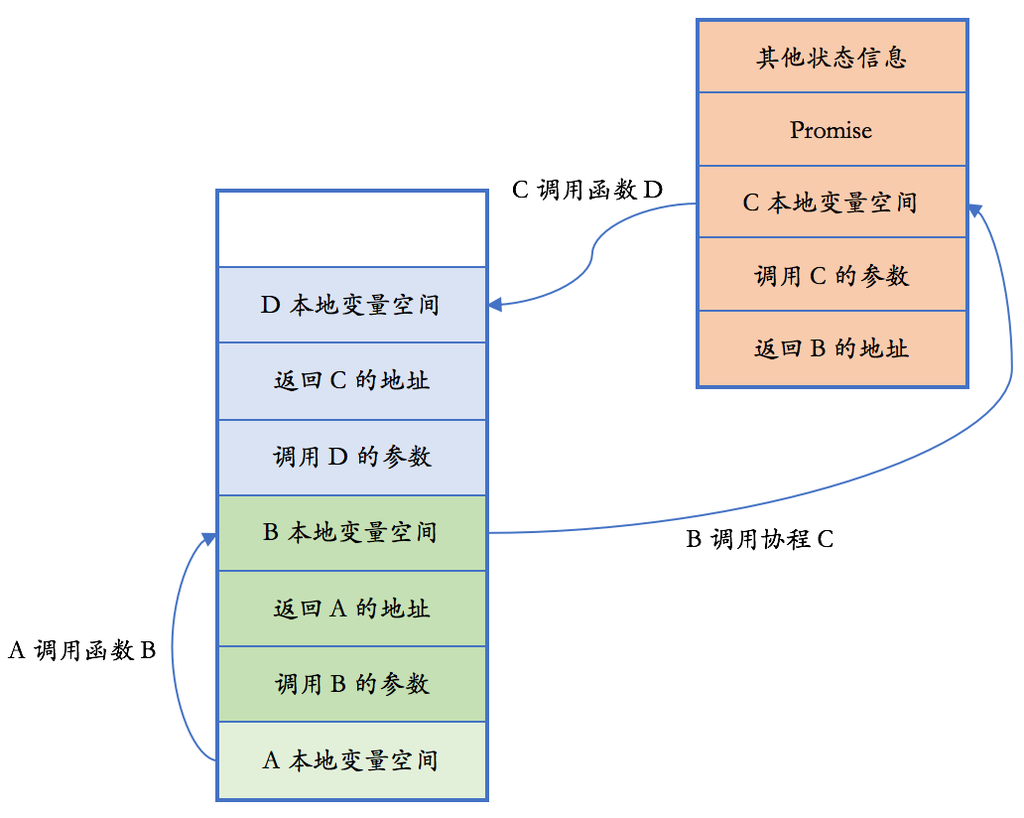

可以看到，协程 C 本身的本地变量不占用栈，但当它调用其他函数时，它会使用线程原先的栈空间。在上面的函数 D 的执行过程中，协程是不可以挂起的——如果控制回到 B 继续，B 可能会使用目前已经被 D 使用的栈空间！

因此，无栈的协程牺牲了一定的灵活性，换来了空间的节省和性能。有栈的协程你可能起几千个就占用不少内存空间，而无栈的协程可以轻轻松松起到亿级——毕竟，维持基本状态的开销我实测下来只有一百字节左右。

反过来，如果无栈的协程不满足需要——比如，你的协程里需要有递归调用，并在深层挂起——你就不得不寻找一个有栈的协程的解决方案。目前已经有一些成熟的方案，比如 Boost.Coroutine2 [4]。下面的代码展示如何在 Boost.Coroutine2 里实现 fibonacci，让你感受一点点小区别：

#include <iostream>

#include <stdint.h>

#include <boost/coroutine2/all.hpp>

typedef boost::coroutines2::

coroutine<const uint64_t>

coro_t;

void fibonacci(

coro_t::push_type& yield)

{

uint64_t a = 0;

uint64_t b = 1;

while (true) {

yield(b);

auto tmp = a;

a = b;

b += tmp;

}

}

int main()

{

for (auto i : coro_t::pull_type(

boost::coroutines2::

fixedsize_stack(),

fibonacci)) {

if (i >= 10000) {

break;

}

std::cout << i << std::endl;

}

}

## 编译器支持

前面提到了，MSVC 和 Clang 目前支持协程。不过，它们都需要特殊的命令行选项来开启协程支持：

MSVC 需要 /await 命令行选项

Clang 需要 -fcoroutines-ts 命令行选项

为了满足使用 CMake 的同学的要求，也为了方便大家编译，我把示例代码放到了 GitHub 上：

https://github.com/adah1972/geek_time_cpp

第一次我只放了第 30 讲的代码，但我会把其他的代码陆续补上。

## 内容小结

本讲讨论了 C++20 里的第三个重要特性：协程。协程仍然很新，但它的重要性是毋庸置疑的——尤其在生成器和异步 I/O 上。

## 课后思考

请仔细比较第一个 fibonacci 的 C++ 实现和最后使用 generator 的 fibonacci 的实现，体会协程代码如果自行用状态机的方式来实现，是一件多麻烦的事情。

如果你对协程有兴趣，可以查看参考资料 [5]，里面提供了一些较为深入的原理介绍。

## 参考资料

[1] 维基百科, “协程”. https://zh.wikipedia.org/zh-cn/ 协程

[2] Gor Nishanov, “Working draft, C++ extensions for coroutines”. http://www.open-std.org/jtc1/sc22/wg21/docs/papers/2018/n4775.pdf

[3] Lewis Baker, CppCoro. https://github.com/lewissbaker/cppcoro

[4] Oliver Kowalke, Boost.Coroutine2. https://www.boost.org/doc/libs/release/libs/coroutine2/doc/html/index.html

[5] Dawid Pilarski, “Coroutines introduction”. https://blog.panicsoftware.com/coroutines-introduction/

[figure not shown]

[figure not shown]

[interactive chart not shown]